# Airbnb: Data Modeling

Tanya Bonilla

11/20/2019

# Predictions

Inititally, I was researching to find out how much people are willing to spend on staying in other people’s homes and the effect it has had on hotels, but due to the fact I could not find data that could answer that question I decided to take another route. I’m predicting that the price of a listing is affected by the amount of bedrooms available.

# Gettting started

We begin by loading in *Airbnb: Tidying the Data* and any library that we plan on using throughout our analysis.

```r
library(rvest)
library(knitr)
library(tidyr)
library(tidyverse)
library(dplyr)
library(caret)
library(jsonlite)
library(ggplot2)

purl("p01_airbnb.Rmd", output = "first_del.r")
source("first_del.r")
```

# Loading and Tidying the Data

We now load in this New York json file we acquired from *Opendatasoft.com* which is a “data sharing platform teams use to access, reuse and share data that grows business.” We utilze the function *fromJSON* from the jsonlite library.

```r
new_york <- fromJSON("airbnb-listings.json")
colnames(new_york)
```

```
## [1] "datasetid"        "recordid"         "fields"
## [4] "geometry"         "record_timestamp"
```

When looking at the file, we see that there are 5 variables:

- **datasetid** - character type with the id of which the data is from
- **recordid** - character type with the recordid of the listing
- **geometry**- dataframe with 2 columns with the listing’s coordinates

```
## [1] "type"        "coordinates"
```

- **fields** - dataframe with 86 variables with details from the listing

```
##  [1] "review_scores_accuracy"         "reviews_per_month"
##  [3] "bathrooms"                      "first_review"
##  [5] "geolocation"                    "cancellation_policy"
##  [7] "accommodates"                   "calendar_last_scraped"
##  [9] "medium_url"                     "host_neighbourhood"
## [11] "street"                         "review_scores_communication"
## [13] "calendar_updated"               "country_code"
## [15] "review_scores_cleanliness"      "property_type"
## [17] "availability_365"               "id"
## [19] "market"                         "features"
## [21] "city"                           "availability_60"
## [23] "picture_url"                    "zipcode"
## [25] "host_location"                  "availability_90"
## [27] "state"                          "thumbnail_url"
## [29] "amenities"                      "host_listings_count"
```

[output cut: 28 more lines]

- **record_timestamp** - character

As we are more interested in the *fields* dataframe within the JSON data, let’s create a tibble that will hold the variables we deem important for modeling.

```r
new_york_fields <- tibble (
  price = new_york$fields$price,
  bathrooms = new_york$fields$bathrooms,
  bedrooms = new_york$fields$bedrooms,
  host_neighbourhood = new_york$fields$host_neighbourhood,
  street = new_york$fields$street,
  property_type = new_york$fields$property_type,
  availability_365  = new_york$fields$availability_365,
  zipcode = new_york$fields$zipcode,
  host_location = new_york$fields$host_location,
  host_listings_count = new_york$fields$host_listings_count,
  neighbourhood_group_cleansed = new_york$fields$neighbourhood_group_cleansed,
  host_id = new_york$fields$host_id,
  neighbourhood = new_york$fields$neighbourhood,
  bed_type = new_york$fields$bed_type,
  calendar_last_scraped = new_york$fields$calendar_last_scraped,
  record_timestamp = new_york$record_timestamp
)
new_york_fields <- new_york_fields %>% drop_na()
```

# Modeling

Now that we have our new dataframe, we can focus on modeling the data. The plan is to find if there is any sort of relationship between the listing’s price and bedrooms as we are looking to see if there is any relationship between the two.

```r
set.seed(385)
sample_selection <- createDataPartition(new_york_fields$price, p = 0.70, list = FALSE)
train <- new_york_fields[sample_selection,]
test <- new_york_fields[-sample_selection,]
train_model <- lm(price ~ bedrooms, data = train)
predictions <- train_model %>% predict(test)
```

Now that we made the model, we can look at the R<sup>2</sup> which is a “…statistical measure of how close the data are to the fitted regression line” and mean absolute error (MAE) which is a “measure of difference between two continuous variables.” The bigger R<sup>2</sup> is the better and the smaller MAE the better.

```r
summary(train_model)
```

```
##
## Call:
## lm(formula = price ~ bedrooms, data = train)
##
## Residuals:
##     Min      1Q  Median      3Q     Max
## -437.91  -76.90  -26.90   49.35  837.10
##
## Coefficients:
##             Estimate Std. Error t value Pr(>|t|)
## (Intercept)   83.143      2.026   41.03   <2e-16 ***
## bedrooms      78.752      1.607   49.00   <2e-16 ***
## ---
## Signif. codes:  0 '***' 0.001 '**' 0.01 '*' 0.05 '.' 0.1 ' ' 1
##
## Residual standard error: 111.7 on 11167 degrees of freedom
## Multiple R-squared:  0.177,  Adjusted R-squared:  0.1769
## F-statistic:  2401 on 1 and 11167 DF,  p-value: < 2.2e-16
```

```r
R2(predictions, test$price)
```

```
## [1] 0.1911161
```

```r
MAE(predictions, test$price)
```

```
## [1] 78.11889
```

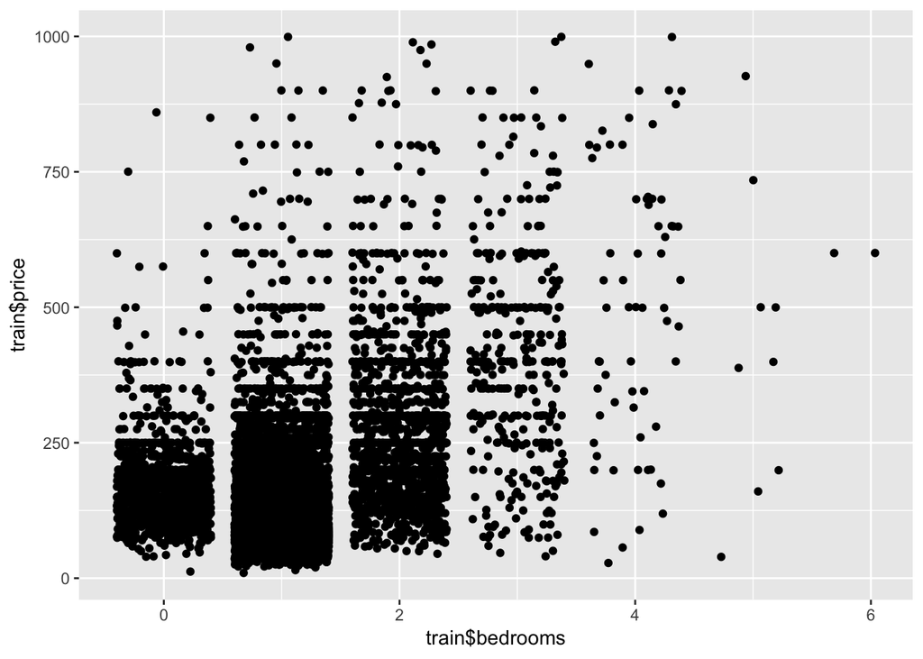

```r
ggplot(train, aes(x = train$bedrooms, y = train$price)) + geom_jitter()
```